# HW4 Solution

Rick Farouni

Oct 1st, 2016

Load required libraries

```r
library(lavaan)
library(semPlot)
```

### EX 1

The following explanation contains material that wasn’t covered at the time when the assignment was handed out, but you should pay attention to it since it provides a big picture for all the models that will be covered in the course.

We can use the *lisrelModel* function (Look [here](http://sachaepskamp.com/semPlot/examples) for examples) in the *semPlot* package to plot the path diagram for the model. We just need to feed the function the matrices with a 1 specifiying a free parameter and zero for fixed parameter. Here is the code:

```r
endogen_N <- 6 # number of endogenous observed variables
exogen_N <- 2 # number of exogenous observed variables
# Beta 3x3 matrix:
Beta <- matrix(c(0, 0, 0, 0, 0, 0,
                 1, 0, 0, 0, 0, 0,
                 1, 1, 0, 0, 0, 0,
                 1, 1, 1, 0, 0, 0,
                 1, 1, 1, 0, 0, 0,
                 0, 0, 0, 1, 1, 0),
                nrow = endogen_N,
                ncol = endogen_N,
                byrow = TRUE)

# Gamma 6x2 matrix :
Gamma <- matrix(c(1, 0,
                  1, 1,
                  0, 0,
                  0, 0,
                  0, 0,
                  0, 0),
                nrow = endogen_N ,
                ncol = exogen_N ,
                byrow = TRUE)

# Psi 6x6  matrix :
Psi <- matrix( c(1, 0, 0, 0, 0, 0,
                 0, 1, 0, 0, 0, 0,
                 0, 0, 1, 0, 0, 0,
                 0, 0, 0, 1, 0, 0,
                 0, 0, 0, 0, 1, 0,
                 0, 0, 0, 0, 0, 1),
                nrow = endogen_N,
                ncol = endogen_N,
                byrow = TRUE)

# Phi 2x2matrix :
Phi <- matrix( c(1, 1,
                 1, 1),
                nrow = exogen_N,
                ncol = exogen_N,
                byrow = TRUE)

# Lambda identity matrices :
Lambda_x <- diag(1,
                 nrow = exogen_N,
                 ncol = exogen_N)
Lambda_y <- diag(1,
                 nrow = endogen_N,
                 ncol = endogen_N)
```

We can print out the matrices first

```r
Beta
```

```
     [,1] [,2] [,3] [,4] [,5] [,6]
[1,]    0    0    0    0    0    0
[2,]    1    0    0    0    0    0
[3,]    1    1    0    0    0    0
[4,]    1    1    1    0    0    0
[5,]    1    1    1    0    0    0
[6,]    0    0    0    1    1    0
```

```r
Gamma
```

```
     [,1] [,2]
[1,]    1    0
[2,]    1    1
[3,]    0    0
[4,]    0    0
[5,]    0    0
[6,]    0    0
```

```r
Psi
```

```
     [,1] [,2] [,3] [,4] [,5] [,6]
[1,]    1    0    0    0    0    0
[2,]    0    1    0    0    0    0
[3,]    0    0    1    0    0    0
[4,]    0    0    0    1    0    0
[5,]    0    0    0    0    1    0
[6,]    0    0    0    0    0    1
```

```r
Phi
```

```
     [,1] [,2]
[1,]    1    1
[2,]    1    1
```

```r
Lambda_x
```

```
     [,1] [,2]
[1,]    1    0
[2,]    0    1
```

```r
Lambda_y
```

```
     [,1] [,2] [,3] [,4] [,5] [,6]
[1,]    1    0    0    0    0    0
[2,]    0    1    0    0    0    0
[3,]    0    0    1    0    0    0
[4,]    0    0    0    1    0    0
[5,]    0    0    0    0    1    0
[6,]    0    0    0    0    0    1
```

Combine the model and plot

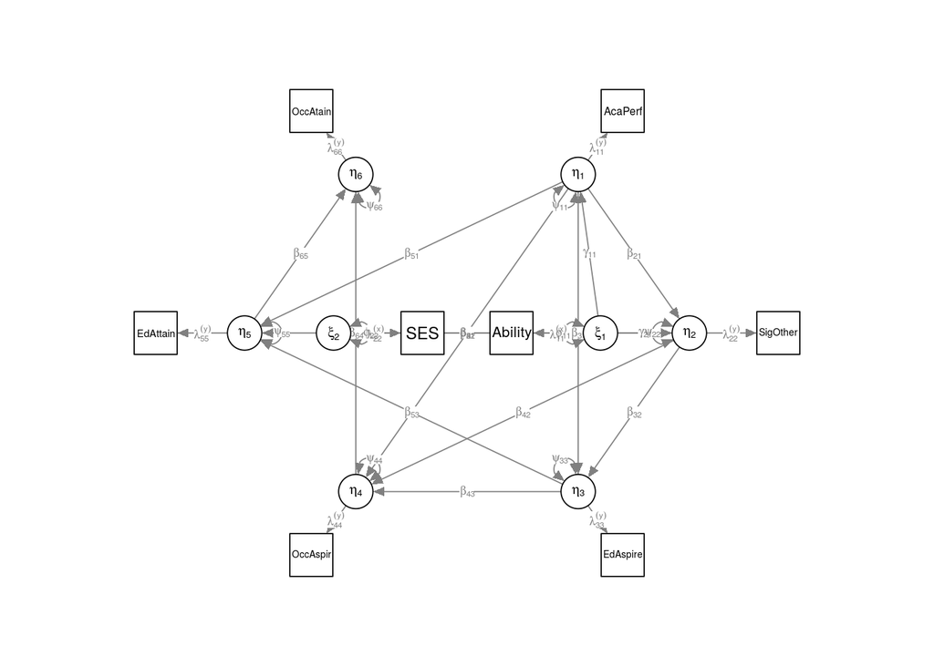

```r
# Combine model:
mod <- lisrelModel(LY = Lambda_y,
                   PS = Psi,
                   BE = Beta,
                   manNamesEndo = c("AcaPerf", "SigOther", "EdAspire", "OccAspir", "EdAttain", "OccAtain"),
                   LX = Lambda_x,
                   PH = Phi,
                   GA = Gamma,
                   manNamesExo = c("Ability", "SES"))
# Plot path diagram:
semPaths(mod,
         as.expression = c("nodes", "edges"),
         layout = "circle",
         sizeMan = 5,  # adjust size of boxes
         sizeInt = 1,
         sizeLat = 4,
         curve = TRUE)
```

### EX 2

First assign the summarized data to a character vector and convert it to a full symmetric covariance/correlation matrix with names

```r
Sample_A <-
' 1
 .225    1
 .534  .181    1
 .456  .344  .505    1
 .404  .377  .442  .632    1
 .429  .367  .473  .594  .767    1
 .467  .382  .548  .640  .681  .632    1
 .373  .308  .372  .460  .450  .468  .581    1 '

N1 <- 935
Sample_A_cor <- getCov(Sample_A,
                  names = c("Ability", "SES", "AcaPerf", "SigOther", "EdAspire", "OccAspir", "EdAttain", "OccAtain"))
```

Specify model

```r
  model1 <- '
     AcaPerf ~ Ability
     SigOther ~ SES + Ability + AcaPerf
     EdAspire ~ AcaPerf + SigOther
     OccAspir ~ AcaPerf + SigOther +  EdAspire
     EdAttain ~ AcaPerf + SigOther +  EdAspire
     OccAtain ~ OccAspir + EdAttain '
```

Fit the model

```r
model1_fit <- sem(model1,
           sample.cov = Sample_A_cor,
           sample.nobs = N1)
```

```
Found more than one class "Model" in cache; using the first, from namespace 'lavaan'
```

```r
summary(model1_fit)
```

```
lavaan (0.5-22) converged normally after  19 iterations

  Number of observations                           935

  Estimator                                         ML
  Minimum Function Test Statistic              145.010
  Degrees of freedom                                13
  P-value (Chi-square)                           0.000

Parameter Estimates:

  Information                                 Expected
  Standard Errors                             Standard

Regressions:
                   Estimate  Std.Err  z-value  P(>|z|)
  AcaPerf ~
    Ability           0.534    0.028   19.313    0.000
  SigOther ~
    SES               0.232    0.027    8.606    0.000
    Ability           0.219    0.032    6.916    0.000
    AcaPerf           0.346    0.031   11.135    0.000
  EdAspire ~
    AcaPerf           0.165    0.029    5.757    0.000
    SigOther          0.549    0.029   19.065    0.000
  OccAspir ~
    AcaPerf           0.129    0.024    5.476    0.000
    SigOther          0.133    0.027    4.862    0.000
    EdAspire          0.626    0.026   23.646    0.000
  EdAttain ~
    AcaPerf           0.234    0.025    9.385    0.000
    SigOther          0.261    0.029    9.012    0.000
    EdAspire          0.413    0.028   14.765    0.000
  OccAtain ~
    OccAspir          0.168    0.032    5.191    0.000
    EdAttain          0.475    0.032   14.680    0.000

Variances:
                   Estimate  Std.Err  z-value  P(>|z|)
   .AcaPerf           0.714    0.033   21.622    0.000
   .SigOther          0.645    0.030   21.622    0.000
   .EdAspire          0.580    0.027   21.622    0.000
   .OccAspir          0.379    0.018   21.622    0.000
   .EdAttain          0.423    0.020   21.622    0.000
   .OccAtain          0.645    0.030   21.622    0.000
```

```r
(modelEst1 <- lavInspect(model1_fit, "est"))
```

```
$lambda
         AcaPrf SgOthr EdAspr OccAsp EdAttn OccAtn Abilty SES
AcaPerf       1      0      0      0      0      0      0   0
SigOther      0      1      0      0      0      0      0   0
EdAspire      0      0      1      0      0      0      0   0
OccAspir      0      0      0      1      0      0      0   0
EdAttain      0      0      0      0      1      0      0   0
OccAtain      0      0      0      0      0      1      0   0
Ability       0      0      0      0      0      0      1   0
SES           0      0      0      0      0      0      0   1

$theta
         AcaPrf SgOthr EdAspr OccAsp EdAttn OccAtn Abilty SES
AcaPerf  0
SigOther 0      0
EdAspire 0      0      0
OccAspir 0      0      0      0
EdAttain 0      0      0      0      0
OccAtain 0      0      0      0      0      0
Ability  0      0      0      0      0      0      0
SES      0      0      0      0      0      0      0      0

$psi
         AcaPrf SgOthr EdAspr OccAsp EdAttn OccAtn Abilty SES
AcaPerf  0.714
SigOther 0.000  0.645
EdAspire 0.000  0.000  0.580
OccAspir 0.000  0.000  0.000  0.379
EdAttain 0.000  0.000  0.000  0.000  0.423
OccAtain 0.000  0.000  0.000  0.000  0.000  0.645
Ability  0.000  0.000  0.000  0.000  0.000  0.000  0.999
SES      0.000  0.000  0.000  0.000  0.000  0.000  0.225  0.999

$beta
         AcaPrf SgOthr EdAspr OccAsp EdAttn OccAtn Abilty   SES
AcaPerf   0.000  0.000  0.000  0.000  0.000      0  0.534 0.000
SigOther  0.346  0.000  0.000  0.000  0.000      0  0.219 0.232
EdAspire  0.165  0.549  0.000  0.000  0.000      0  0.000 0.000
OccAspir  0.129  0.133  0.626  0.000  0.000      0  0.000 0.000
EdAttain  0.234  0.261  0.413  0.000  0.000      0  0.000 0.000
OccAtain  0.000  0.000  0.000  0.168  0.475      0  0.000 0.000
Ability   0.000  0.000  0.000  0.000  0.000      0  0.000 0.000
SES       0.000  0.000  0.000  0.000  0.000      0  0.000 0.000
```

Note that in lavaan the psi matrix corresponds to the following compound matrix in the notes

$$\begin{bmatrix}
\boldsymbol \Psi & \mathbf 0\\
\mathbf 0 & \boldsymbol \Phi
\end{bmatrix}$$

and the beta matrix to

$$\begin{bmatrix}
\mathbf B & \boldsymbol \Gamma\\
\mathbf 0 & \mathbf 0
\end{bmatrix}$$

Please extract them

```r
(Psi   <- modelEst1$psi[1:6, 1:6])
```

```
         AcaPerf SigOther EdAspire OccAspir EdAttain OccAtain
AcaPerf    0.714    0.000     0.00    0.000    0.000    0.000
SigOther   0.000    0.645     0.00    0.000    0.000    0.000
EdAspire   0.000    0.000     0.58    0.000    0.000    0.000
OccAspir   0.000    0.000     0.00    0.379    0.000    0.000
EdAttain   0.000    0.000     0.00    0.000    0.423    0.000
OccAtain   0.000    0.000     0.00    0.000    0.000    0.645
```

```r
(Phi   <- modelEst1$psi[7:8, 7:8])
```

```
        Ability   SES
Ability   0.999 0.225
SES       0.225 0.999
```

```r
(Beta  <- modelEst1$beta[1:6, 1:6])
```

```
         AcaPerf SigOther EdAspire OccAspir EdAttain OccAtain
AcaPerf    0.000    0.000    0.000    0.000    0.000        0
SigOther   0.346    0.000    0.000    0.000    0.000        0
EdAspire   0.165    0.549    0.000    0.000    0.000        0
OccAspir   0.129    0.133    0.626    0.000    0.000        0
EdAttain   0.234    0.261    0.413    0.000    0.000        0
OccAtain   0.000    0.000    0.000    0.168    0.475        0
```

```r
(Gamma <- modelEst1$beta[1:6, 7:8])
```

```
         Ability   SES
AcaPerf    0.534 0.000
SigOther   0.219 0.232
EdAspire   0.000 0.000
OccAspir   0.000 0.000
EdAttain   0.000 0.000
OccAtain   0.000 0.000
```

Print the residuals using the *resid* function and set the type option either to “standardized”,“normalized”, “cor” or “raw”. These are the standardized, normalized, correlation transformed, or the raw unstandardized difference between the implied moments and the observed correlation matrix. Inverstigate which one is appropriate and report it (hint: the summary data is a correlation matrix)

```r
resid(model1_fit, type = "raw")
```

```
$type
[1] "raw"

$cov
         AcaPrf SgOthr EdAspr OccAsp EdAttn OccAtn Abilty SES
AcaPerf  0.000
SigOther 0.014  0.010
EdAspire 0.008  0.008  0.005
OccAspir 0.007  0.008  0.005  0.005
EdAttain 0.007  0.009  0.006  0.056  0.006
OccAtain 0.037  0.062  0.002  0.027  0.012  0.010
Ability  0.000  0.000  0.066  0.087  0.083  0.133  0.000
SES      0.061  0.021  0.180  0.185  0.188  0.185  0.000  0.000

$mean
 AcaPerf SigOther EdAspire OccAspir EdAttain OccAtain  Ability      SES
       0        0        0        0        0        0        0        0
```

Print the three fit measures (T_ml , df , RMSEA) using the *fitMeasures* function with the correct argument in the *fit.measures* option. Note that the ML test statistic T_ml (test of exact fit) is obtained using the likelihood ratio test between the saturated model (the model with degrees of freedom df = 0) and the hypothesized model which has a positive df. Under the assumptions of proper model specification, multivariate normality, and sufficiently large samlple size, T_ml follows a chi-square distribution. The RMSEA, on the otherhand, is a measure of lack of fit with an adjustment for nodel parsimony.

```r
fitMeasures(model1_fit, fit.measures = c("chisq", "df", "rmsea"))
```

```
  chisq      df   rmsea
145.010  13.000   0.104
```

### EX 3

Use the the *modificationIndices* function and pay attention to the expected parameter change (epc) and the modification index (mi) values

```r
modificationIndices(model1_fit,
                    standardized = FALSE,
                    sort. = TRUE)
```

```
        lhs op      rhs     mi    epc
47 SigOther  ~ EdAttain 61.319 -0.765
46 SigOther  ~ OccAspir 55.111 -0.673
45 SigOther  ~ EdAspire 47.181 -0.637
29 SigOther ~~ EdAspire 47.181 -0.369
53 EdAspire  ~      SES 45.286  0.177
78      SES  ~ EdAttain 34.646  0.208
76      SES  ~ EdAspire 34.637  0.213
77      SES  ~ OccAspir 32.946  0.202
31 SigOther ~~ EdAttain 28.934 -0.247
79      SES  ~ OccAtain 26.108  0.171
61 EdAttain  ~      SES 21.976  0.106
30 SigOther ~~ OccAspir 16.587 -0.177
58 EdAttain  ~ OccAspir 14.418  0.131
54 OccAspir  ~ EdAttain 14.418  0.118
```

[output cut: 41 more lines]

Model improvement. Modify the model

```r
  model2 <- '
     AcaPerf ~ Ability
     SigOther ~ SES + Ability + AcaPerf
     EdAspire ~ AcaPerf + SigOther
     OccAspir ~ AcaPerf + SigOther +  EdAspire
     EdAttain ~ AcaPerf + SigOther +  EdAspire
     OccAtain ~ OccAspir + EdAttain
     SigOther ~~ EdAspire'
```

and the corresponding model matrices

```r
endogen_N <- 6 # number of endogenous observed variables
exogen_N <- 2 # number of exogenous observed variables
# Beta 3x3 matrix:
Beta <- matrix(c(0, 0, 0, 0, 0, 0,
                 1, 0, 0, 0, 0, 0,
                 1, 1, 0, 0, 0, 0,
                 1, 1, 1, 0, 0, 0,
                 1, 1, 1, 0, 0, 0,
                 0, 0, 0, 1, 1, 0),
                nrow = endogen_N,
                ncol = endogen_N,
                byrow = TRUE)

# Gamma 6x2 matrix :
Gamma <- matrix(c(1, 0,
                  1, 1,
                  0, 0,
                  0, 0,
                  0, 0,
                  0, 0),
                nrow = endogen_N ,
                ncol = exogen_N ,
                byrow = TRUE)

# Psi 6x6 diagonal matrix :
Psi <- matrix( c(1, 0, 0, 0, 0, 0,
                 0, 1, 1, 0, 0, 0,
                 0, 1, 1, 0, 0, 0,
                 0, 0, 0, 1, 0, 0,
                 0, 0, 0, 0, 1, 0,
                 0, 0, 0, 0, 0, 1),
                nrow = endogen_N,
                ncol = endogen_N,
                byrow = TRUE)

# Phi 2x2 diagonal matrix :
Phi <- matrix( c(1, 0,
                 0, 1),
                nrow = exogen_N,
                ncol = exogen_N,
                byrow = TRUE)

# Lambda identity matrices :
Lambda_x <- diag(1,
                 nrow = exogen_N,
                 ncol = exogen_N)
Lambda_y <- diag(1,
                 nrow = endogen_N,
                 ncol = endogen_N)
```

We can print out the matrices first

```r
Beta
```

```
     [,1] [,2] [,3] [,4] [,5] [,6]
[1,]    0    0    0    0    0    0
[2,]    1    0    0    0    0    0
[3,]    1    1    0    0    0    0
[4,]    1    1    1    0    0    0
[5,]    1    1    1    0    0    0
[6,]    0    0    0    1    1    0
```

```r
Gamma
```

```
     [,1] [,2]
[1,]    1    0
[2,]    1    1
[3,]    0    0
[4,]    0    0
[5,]    0    0
[6,]    0    0
```

```r
Psi
```

```
     [,1] [,2] [,3] [,4] [,5] [,6]
[1,]    1    0    0    0    0    0
[2,]    0    1    1    0    0    0
[3,]    0    1    1    0    0    0
[4,]    0    0    0    1    0    0
[5,]    0    0    0    0    1    0
[6,]    0    0    0    0    0    1
```

```r
Phi
```

```
     [,1] [,2]
[1,]    1    0
[2,]    0    1
```

```r
Lambda_x
```

```
     [,1] [,2]
[1,]    1    0
[2,]    0    1
```

```r
Lambda_y
```

```
     [,1] [,2] [,3] [,4] [,5] [,6]
[1,]    1    0    0    0    0    0
[2,]    0    1    0    0    0    0
[3,]    0    0    1    0    0    0
[4,]    0    0    0    1    0    0
[5,]    0    0    0    0    1    0
[6,]    0    0    0    0    0    1
```

Combine the model and plot

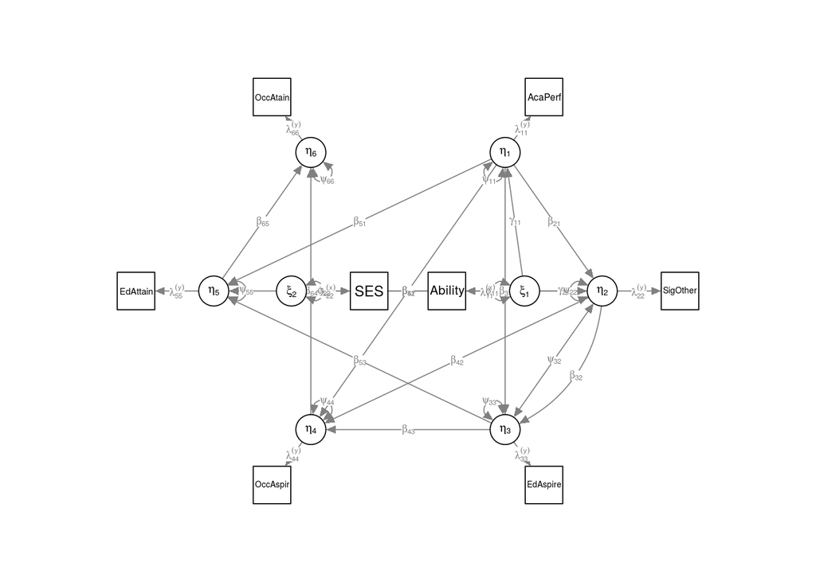

```r
# Combine model:
mod2 <- lisrelModel(LY = Lambda_y,
                   PS = Psi,
                   BE = Beta,
                   manNamesEndo = c("AcaPerf", "SigOther", "EdAspire", "OccAspir", "EdAttain", "OccAtain"),
                   LX = Lambda_x,
                   PH = Phi,
                   GA = Gamma,
                   manNamesExo = c("Ability", "SES"))
# Plot path diagram:
semPaths(mod2,
         as.expression = c("nodes", "edges"),
         layout = "circle",
         sizeMan = 5,  # adjust size of boxes
         sizeInt = 1,
         sizeLat = 4,
         curve = TRUE)
```

### EX 4

Read data for Sample B

```r
Sample_B <- '
  1
 .292    1
 .501  .172    1
 .407  .259  .426    1
 .403  .332  .419  .552    1
 .435  .297  .457  .510  .731    1
 .512  .381  .490  .552  .649  .580    1
 .344  .295  .330  .383  .430  .445  .587    1'

N2 <- 686
Sample_B_cor <- getCov(Sample_B,
                  names = c("Ability", "SES", "AcaPerf", "SigOther", "EdAspire", "OccAspir", "EdAttain", "OccAtain"))
```

Fit the model with Sample A

```r
model2A_fit <- sem(model2,
           sample.cov = Sample_A_cor,
           sample.nobs = N1)
summary(model2A_fit)
```

```
lavaan (0.5-22) converged normally after  27 iterations

  Number of observations                           935

  Estimator                                         ML
  Minimum Function Test Statistic               93.488
  Degrees of freedom                                12
  P-value (Chi-square)                           0.000

Parameter Estimates:

  Information                                 Expected
  Standard Errors                             Standard

Regressions:
                   Estimate  Std.Err  z-value  P(>|z|)
  AcaPerf ~
    Ability           0.534    0.028   19.313    0.000
  SigOther ~
    SES               0.249    0.025    9.879    0.000
    Ability           0.193    0.028    6.944    0.000
    AcaPerf           0.357    0.030   11.767    0.000
  EdAspire ~
    AcaPerf          -0.101    0.053   -1.913    0.056
    SigOther          1.076    0.090   11.902    0.000
  OccAspir ~
    AcaPerf           0.129    0.024    5.489    0.000
    SigOther          0.133    0.027    4.856    0.000
    EdAspire          0.626    0.026   23.670    0.000
  EdAttain ~
    AcaPerf           0.234    0.025    9.407    0.000
    SigOther          0.261    0.029    9.001    0.000
    EdAspire          0.413    0.028   14.780    0.000
  OccAtain ~
    OccAspir          0.168    0.032    5.189    0.000
    EdAttain          0.475    0.032   14.677    0.000

Covariances:
                   Estimate  Std.Err  z-value  P(>|z|)
 .SigOther ~~
   .EdAspire         -0.392    0.064   -6.117    0.000

Variances:
                   Estimate  Std.Err  z-value  P(>|z|)
   .AcaPerf           0.714    0.033   21.622    0.000
   .SigOther          0.645    0.030   21.622    0.000
   .EdAspire          0.786    0.080    9.869    0.000
   .OccAspir          0.379    0.018   21.622    0.000
   .EdAttain          0.423    0.020   21.622    0.000
   .OccAtain          0.645    0.030   21.622    0.000
```

Fit the model with Sample B

```r
model2B_fit <- sem(model2,
           sample.cov = Sample_B_cor,
           sample.nobs = N2)
summary(model2B_fit)
```

```
lavaan (0.5-22) converged normally after  28 iterations

  Number of observations                           686

  Estimator                                         ML
  Minimum Function Test Statistic               90.407
  Degrees of freedom                                12
  P-value (Chi-square)                           0.000

Parameter Estimates:

  Information                                 Expected
  Standard Errors                             Standard

Regressions:
                   Estimate  Std.Err  z-value  P(>|z|)
  AcaPerf ~
    Ability           0.501    0.033   15.162    0.000
  SigOther ~
    SES               0.175    0.030    5.873    0.000
    Ability           0.183    0.033    5.497    0.000
    AcaPerf           0.304    0.037    8.141    0.000
  EdAspire ~
    AcaPerf          -0.088    0.076   -1.161    0.245
    SigOther          1.189    0.152    7.822    0.000
  OccAspir ~
    AcaPerf           0.157    0.028    5.517    0.000
    SigOther          0.109    0.031    3.513    0.000
    EdAspire          0.605    0.031   19.541    0.000
  EdAttain ~
    AcaPerf           0.213    0.030    7.006    0.000
    SigOther          0.219    0.033    6.607    0.000
    EdAspire          0.439    0.033   13.288    0.000
  OccAtain ~
    OccAspir          0.158    0.036    4.376    0.000
    EdAttain          0.496    0.036   13.768    0.000

Covariances:
                   Estimate  Std.Err  z-value  P(>|z|)
 .SigOther ~~
   .EdAspire         -0.599    0.121   -4.941    0.000

Variances:
                   Estimate  Std.Err  z-value  P(>|z|)
   .AcaPerf           0.748    0.040   18.520    0.000
   .SigOther          0.750    0.040   18.520    0.000
   .EdAspire          1.092    0.192    5.703    0.000
   .OccAspir          0.430    0.023   18.520    0.000
   .EdAttain          0.489    0.026   18.520    0.000
   .OccAtain          0.638    0.034   18.520    0.000
```

print the coefficients

```r
(coef_2A <- coef(model2A_fit))
```

```
   AcaPerf~Ability       SigOther~SES   SigOther~Ability
             0.534              0.249              0.193
  SigOther~AcaPerf   EdAspire~AcaPerf  EdAspire~SigOther
             0.357             -0.101              1.076
  OccAspir~AcaPerf  OccAspir~SigOther  OccAspir~EdAspire
             0.129              0.133              0.626
  EdAttain~AcaPerf  EdAttain~SigOther  EdAttain~EdAspire
             0.234              0.261              0.413
 OccAtain~OccAspir  OccAtain~EdAttain SigOther~~EdAspire
             0.168              0.475             -0.392
  AcaPerf~~AcaPerf SigOther~~SigOther EdAspire~~EdAspire
             0.714              0.645              0.786
OccAspir~~OccAspir EdAttain~~EdAttain OccAtain~~OccAtain
             0.379              0.423              0.645
```

```r
(coef_2B <- coef(model2B_fit))
```

```
   AcaPerf~Ability       SigOther~SES   SigOther~Ability
             0.501              0.175              0.183
  SigOther~AcaPerf   EdAspire~AcaPerf  EdAspire~SigOther
             0.304             -0.088              1.189
  OccAspir~AcaPerf  OccAspir~SigOther  OccAspir~EdAspire
             0.157              0.109              0.605
  EdAttain~AcaPerf  EdAttain~SigOther  EdAttain~EdAspire
             0.213              0.219              0.439
 OccAtain~OccAspir  OccAtain~EdAttain SigOther~~EdAspire
             0.158              0.496             -0.599
  AcaPerf~~AcaPerf SigOther~~SigOther EdAspire~~EdAspire
             0.748              0.750              1.092
OccAspir~~OccAspir EdAttain~~EdAttain OccAtain~~OccAtain
             0.430              0.489              0.638
```

```r
cbind(coef_2A, coef_2B)
```

```
                   coef_2A coef_2B
AcaPerf~Ability      0.534  0.5010
SigOther~SES         0.249  0.1746
SigOther~Ability     0.193  0.1832
SigOther~AcaPerf     0.357  0.3042
EdAspire~AcaPerf    -0.101 -0.0877
EdAspire~SigOther    1.076  1.1895
OccAspir~AcaPerf     0.129  0.1570
OccAspir~SigOther    0.133  0.1092
OccAspir~EdAspire    0.626  0.6049
EdAttain~AcaPerf     0.234  0.2128
EdAttain~SigOther    0.261  0.2191
EdAttain~EdAspire    0.413  0.4389
OccAtain~OccAspir    0.168  0.1575
OccAtain~EdAttain    0.475  0.4956
SigOther~~EdAspire  -0.392 -0.5992
AcaPerf~~AcaPerf     0.714  0.7479
SigOther~~SigOther   0.645  0.7495
EdAspire~~EdAspire   0.786  1.0924
OccAspir~~OccAspir   0.379  0.4297
EdAttain~~EdAttain   0.423  0.4892
OccAtain~~OccAtain   0.645  0.6380
```

Print the three fit measures

```r
fit_idx_2A <- fitMeasures(model2A_fit, fit.measures = c("chisq", "df", "rmsea"))
fit_idx_2B <- fitMeasures(model2B_fit, fit.measures = c("chisq", "df", "rmsea"))
cbind(fit_idx_2A,fit_idx_2B)
```

```
      fit_idx_2A fit_idx_2B
chisq    93.4885    90.4074
df       12.0000    12.0000
rmsea     0.0852     0.0976
```

print the residuals

```r
resid_2A <- resid(model2A_fit, type = "raw")
(resid_2A$cov)
```

```
         AcaPrf SgOthr EdAspr OccAsp EdAttn OccAtn Abilty SES
AcaPerf   0.000
SigOther  0.015  0.011
EdAspire  0.016  0.010  0.009
OccAspir  0.012  0.010  0.009  0.009
EdAttain  0.011  0.010  0.010  0.059  0.009
OccAtain  0.039  0.063  0.004  0.029  0.014  0.012
Ability   0.000  0.016 -0.015  0.039  0.054  0.112  0.000
SES       0.061  0.009  0.029  0.089  0.123  0.138  0.000  0.000
```

```r
resid_2B <- resid(model2B_fit, type = "raw")
(resid_2B$cov)
```

```
         AcaPrf SgOthr EdAspr OccAsp EdAttn OccAtn Abilty SES
AcaPerf   0.000
SigOther  0.004  0.003
EdAspire  0.005  0.003  0.003
OccAspir  0.004  0.003  0.003  0.003
EdAttain  0.003  0.003  0.003  0.053  0.003
OccAtain  0.017  0.031 -0.005  0.027  0.010  0.009
Ability   0.000  0.020 -0.013  0.062  0.138  0.100  0.000
SES       0.026 -0.014  0.021  0.056  0.153  0.144  0.000  0.000
```

```r
resid_2A$cov - resid_2B$cov
```

```
         AcaPrf SgOthr EdAspr OccAsp EdAttn OccAtn Abilty SES
AcaPerf   0.000
SigOther  0.011  0.008
EdAspire  0.011  0.007  0.006
OccAspir  0.008  0.007  0.006  0.006
EdAttain  0.007  0.008  0.007  0.006  0.007
OccAtain  0.022  0.032  0.009  0.003  0.005  0.003
Ability   0.000 -0.004 -0.002 -0.023 -0.084  0.012  0.000
SES       0.035  0.023  0.008  0.033 -0.031 -0.006  0.000  0.000
```